# 코로나 바이러스(COVID-19) EDA

[figure not shown]

```python
from IPython.display import Image
Image('unnamed1.jpg')
```

# 목차

- 코로나 바이러스란
- 세계 속 코로나 바이러스
- 한국이 잘 대처하고 있다고 주목 받는 이유는 무엇일까?
- 치사율이 낮은 이유
- 확진자가 감소한 이유

# 코로나 바이러스란

- 2019년 12월 중국 우한에서 처음 발생한 이후 중국 전역과 전 세계로 확산된, 새로운 유형의 코로나바이러스(SARS-CoV-2)에 의한 호흡기 감염질환이다.
- 코로나바이러스감염증-19는 감염자의 비말(침방울)이 호흡기나 눈·코·입의 점막으로 침투될 때 전염된다. 감염되면 약 2~14일(추정)의 잠복기를 거친 뒤 발열(37.5도) 및 기침이나 호흡곤란 등 호흡기 증상, 폐렴이 주증상으로 나타나지만 무증상 감염 사례도 드물게 나오고 있다. [네이버 지식백과] 코로나바이러스감염증-19 - (COVID-19) (시사상식사전, pmg 지식엔진연구소)

# 세계 속 코로나 바이러스(2020-03-22기준)

- 데이터 : [kaggle, COVID-19 Complete Dataset](https://www.kaggle.com/imdevskp/corona-virus-report)

### 라이브러리 불러오기

- numpy, pandas로 전처리 및 분석
- seaborn, plotly로 시각화

```python
import numpy as np
import pandas as pd

# 시각화
import seaborn as sns
import plotly.graph_objects as go
import plotly.express as px
import plotly.io as pio
from plotly.subplots import make_subplots
import matplotlib.pyplot as plt

# 경고 숨김
import warnings
warnings.filterwarnings('ignore')

# 한글폰트 사용
plt.rc('font', family = 'Malgun Gothic')
plt.rc('axes', unicode_minus = False)

# 레티나 설정
from IPython.display import set_matplotlib_formats
set_matplotlib_formats('retina')
```

```python
cleaned_data = pd.read_csv('data/covid_19_clean_complete.csv', parse_dates=['Date'])
cleaned_data.head()
```

|  | Province/State | Country/Region | Lat | Long | Date | Confirmed | Deaths | Recovered |
| --- | --- | --- | --- | --- | --- | --- | --- | --- |
| 0 | NaN | Thailand | 15.0000 | 101.0000 | 2020-01-22 | 2 | 0 | 0 |
| 1 | NaN | Japan | 36.0000 | 138.0000 | 2020-01-22 | 2 | 0 | 0 |
| 2 | NaN | Singapore | 1.2833 | 103.8333 | 2020-01-22 | 0 | 0 | 0 |
| 3 | NaN | Nepal | 28.1667 | 84.2500 | 2020-01-22 | 0 | 0 | 0 |
| 4 | NaN | Malaysia | 2.5000 | 112.5000 | 2020-01-22 | 0 | 0 | 0 |

```python
cleaned_data.rename(columns={'ObservationDate': 'date',
                     'Province/State':'state',
                     'Country/Region':'country',
                     'Last Update':'last_updated',
                     'Confirmed': 'confirmed',
                     'Deaths':'deaths',
                     'Recovered':'recovered'
                    }, inplace=True)

# cases
cases = ['confirmed', 'deaths', 'recovered', 'active']

# 현재 환자(Active Case) = confirmed - deaths - recovered
cleaned_data['active'] = cleaned_data['confirmed'] - cleaned_data['deaths'] - cleaned_data['recovered']

# Mainland china를 China로 변경
cleaned_data['country'] = cleaned_data['country'].replace('Mainland China', 'China')

# 결측값 처리
cleaned_data[['state']] = cleaned_data[['state']].fillna('')
cleaned_data[cases] = cleaned_data[cases].fillna(0)
cleaned_data.rename(columns={'Date':'date'}, inplace=True)

data = cleaned_data
```

### 세계 현황(2020-03-22 00시 기준)

- 누적 확진자 : 335,955명
- 사망자 : 14,632명
- 격리해제자 : 97,704명
- 현재 환자 : 223,619명

```python
world = cleaned_data.groupby('date')['confirmed', 'deaths', 'recovered', 'active'].sum().reset_index()
world = world[world['date']==max(world['date'])].reset_index(drop=True)
world
```

|  | date | confirmed | deaths | recovered | active |
| --- | --- | --- | --- | --- | --- |
| 0 | 2020-03-22 | 335955 | 14632 | 97704 | 223619 |

### 트리맵

```python
tm = world.melt(id_vars="date", value_vars=['active', 'deaths', 'recovered'])
fig = px.treemap(tm, path=["variable"], values="value", height=400, width=600,
                 color_discrete_sequence=['#fe9801', '#21bf73', '#ff2e63'])
fig.show()
```

[interactive chart not shown]

```python
grouped = data.groupby('date')['date', 'confirmed', 'deaths'].sum().reset_index()

fig = px.line(grouped, x="date", y="confirmed",
              title="전 세계 확진자 수")
fig.show()
```

[interactive chart not shown]

```python
data['state'] = data['state'].fillna('')
temp = data[[col for col in data.columns if col != 'state']]

latest = temp[temp['date'] == max(temp['date'])].reset_index()
latest_grouped = latest.groupby('country')['confirmed', 'deaths', 'active', 'recovered'].sum().reset_index()
```

```python
fig = px.choropleth(latest_grouped, locations="country",
                    locationmode='country names', color="confirmed",
                    hover_name="country", range_color=[1,5000],
                    color_continuous_scale="peach",
                    title='국가별 확진자 수 히트맵')
fig.show()
```

[interactive chart not shown]

```python
fig = px.bar(latest_grouped.sort_values('confirmed', ascending=False)[:10][::-1],
             x='confirmed', y='country',
             title='전 세계 확진자 수 상위 10개국', text='confirmed', orientation='h')
fig.update_traces(marker_color='#A4D8D4')

fig.show()
```

[interactive chart not shown]

```python
fig = px.line(grouped, x="date", y="deaths", title="전 세계 사망자 수",
             color_discrete_sequence=['#F42272'])
fig.show()
```

[interactive chart not shown]

```python
fig = px.choropleth(latest_grouped, locations="country",
                    locationmode='country names', color="deaths",
                    hover_name="deaths", range_color=[1,100],
                    color_continuous_scale="peach",
                    title='국가별 사망자 수 히트맵')

fig.show()
```

[interactive chart not shown]

```python
fig = px.bar(latest_grouped.sort_values('deaths', ascending=False)[:10][::-1],
             x='deaths', y='country',
             title='전 세계 사망자 수 상위 10개국', text='deaths', orientation='h')
fig.update_traces(marker_color='#ff2e63')
fig.show()
```

[interactive chart not shown]

```python
fig = px.bar(latest_grouped.sort_values('active', ascending=False)[:10][::-1],
             x='active', y='country',
             title='전 세계 현재 환자 수 상위 10개국', text='active', orientation='h')
fig.update_traces(marker_color='#fe9801')
fig.show()
```

[interactive chart not shown]

```python
fig = px.bar(latest_grouped.sort_values('recovered', ascending=False)[:10][::-1],
             x='recovered', y='country',
             title='전 세계 회복자 상위 10개국', text='recovered', orientation='h')
fig.update_traces(marker_color='#21bf73')
fig.show()
```

[interactive chart not shown]

### 치사율 그래프

- 대한민국의 누적 확진자 수는 상위 10개 국가 안에 들어가지만, 치사율은 세계에서 35번째이다.
- 대한민국의 치사율은 1.17%로 전 세계 평균 4.37%의 약 4배 낮은 수준이다.

```python
cleaned_latest = cleaned_data[cleaned_data['date'] == max(cleaned_data['date'])]
flg = cleaned_latest.groupby('country')['confirmed', 'deaths', 'recovered', 'active'].sum().reset_index()

flg['mortalityRate'] = round((flg['deaths']/flg['confirmed'])*100, 2)
temp = flg[flg['confirmed']>100]
temp = temp.sort_values('mortalityRate', ascending=False)

fig = px.bar(temp.sort_values(by="mortalityRate", ascending=False)[:35][::-1],
             x = 'mortalityRate', y = 'country',
             title='전 세계 치사율', text='mortalityRate', height = 800, orientation='h',
             color_discrete_sequence=['darkred']
            )
fig.show()
```

[interactive chart not shown]

# 세계에서 대한민국이 잘 대처하고 있다고 주목 받는 이유는 무엇일까?

- [WHO "한국, 코로나19 대응 교과서 같은 우수사례"](https://www.yonhapnewstv.co.kr/news/MYH20200322003900038)
- [스페인 총리도 "한국 코로나19 대응 방식 배우겠다"](http://www.hani.co.kr/arti/politics/bluehouse/934009.html)
- [외신, 코로나19 대응은 한국이 '롤모델'](http://www.kocis.go.kr/koreanet/view.do?seq=1034755)
- [WP칼럼 "한국의 코로나19 대응, 민주주의 강점 보여줘"](https://news.joins.com/article/23728338)
- 확진자 대비 치사율이 낮은 이유와 기하급수적으로 증가하던 확진자가 감소하는 이유를 알아보자

# 대한민국 확진자 데이터 EDA(2020-03-22기준)

- 데이터 : [kaggle, Data Science for COVID-19 (DS4C)](https://www.kaggle.com/kimjihoo/coronavirusdataset)

```python
df_age = pd.read_csv('data/TimeAge.csv')
```

```python
df_age.tail(9)
```

|  | date | time | age | confirmed | deceased |
| --- | --- | --- | --- | --- | --- |
| 180 | 2020-03-22 | 0 | 0s | 101 | 0 |
| 181 | 2020-03-22 | 0 | 10s | 460 | 0 |
| 182 | 2020-03-22 | 0 | 20s | 2396 | 0 |
| 183 | 2020-03-22 | 0 | 30s | 909 | 1 |
| 184 | 2020-03-22 | 0 | 40s | 1221 | 1 |
| 185 | 2020-03-22 | 0 | 50s | 1691 | 7 |
| 186 | 2020-03-22 | 0 | 60s | 1132 | 17 |
| 187 | 2020-03-22 | 0 | 70s | 595 | 37 |
| 188 | 2020-03-22 | 0 | 80s | 392 | 41 |

```python
age_list = df_age.age.unique()
ages = df_age.groupby('age')['age','confirmed','deceased'].max()
ages['mortality'] = (ages['deceased'] / ages['confirmed']) * 100
```

### 연령대별 누적 확진자 수

- 누적 확진자 수는 20대가 가장 많다.

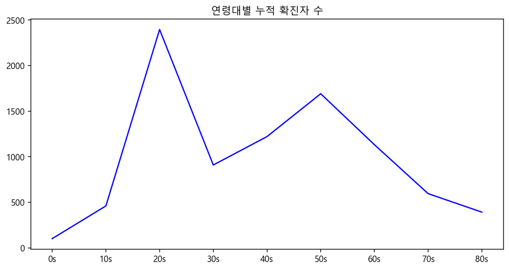

```python
plt.figure(figsize=(10,5))
plt.title('연령대별 누적 확진자 수')
plt.plot(age_list, df_age.confirmed[-9:], color='b')
```

```python
fig = px.line(ages, x="age", y="confirmed", title="연령대별 누적 확진자 수")
fig.show()
```

[interactive chart not shown]

### 연령대별 사망자 수

- 확진자 수와 사망자 수는 비례하지 않았다.
- 비교적 확진자 수가 적은 60세 이상 환자가 대부분 사망하였다.

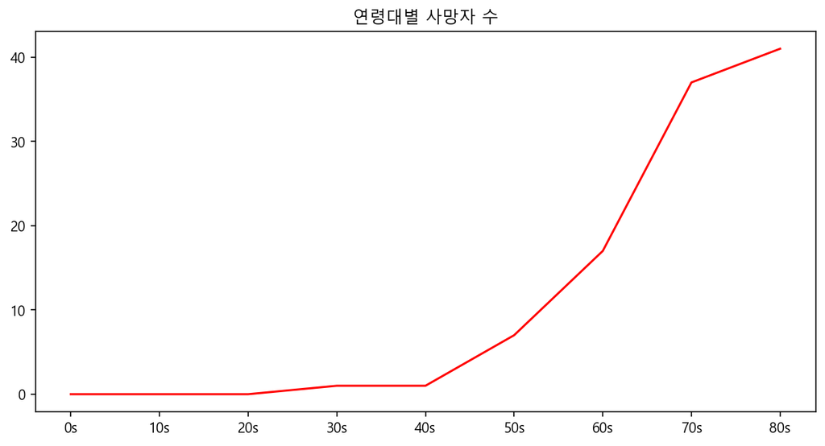

```python
plt.figure(figsize=(10,5))
plt.title('연령대별 사망자 수')
plt.plot(age_list, df_age.deceased[-9:], color='r')
```

```python
fig = px.line(ages, x='age', y="deceased", title="연령대별 사망자 수",
             color_discrete_sequence=['#F42272'])
fig.show()
```

[interactive chart not shown]

### 연령대별 치사율

- 70세 이상 환자의 치사율은 세계 평균보다 훨씬 높았다.
- [코로나19 사망 1위 이탈리아, 사망자 평균나이 78.5세](http://www.donga.com/news/article/all/20200321/100262599/1)
- 최근 사망자 수가 중국을 뛰어넘은 이탈리아의 경우 사망자 평균나이가 78.5세이다.
- 세계적으로 보아도 코로나 바이러스의 치사율은 고령 환자에게 높다
- 한국의 확진자는 대부분 젊은 연령이기 때문에 비교적 치사율이 낮다고 볼 수 있다.

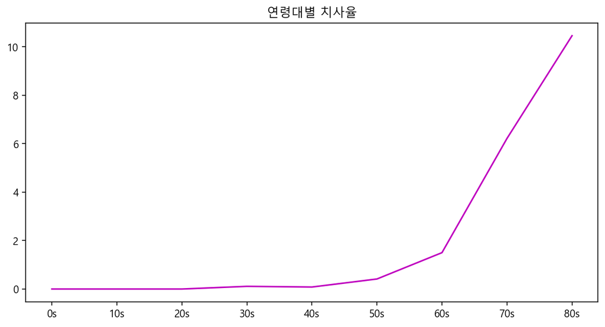

```python
plt.figure(figsize=(10,5))
plt.title('연령대별 치사율')
plt.plot(age_list, ages.mortality[-9:], color='m')
```

```python
fig = px.line(ages, x='age', y="mortality", title="연령대별 치사율",
             color_discrete_sequence=['#b304bd'])
fig.show()
```

[interactive chart not shown]